# Midterm

Mohammad Shehab

4/1/2020

# Introduction

On April 15, 1912, the largest passenger liner ever made collided with an iceberg during her maiden voyage. When the Titanic sank it killed 1502 out of 2224 passengers and crew. This sensational tragedy shocked the international community and led to better safety regulations for ships. One of the reasons that the shipwreck resulted in such loss of life was that there were not enough lifeboats for the passengers and crew. Although there was some element of luck involved in surviving the sinking, some groups of people were more likely to survive than others.

The titanic.csv file contains data for 1310 of the real Titanic passengers. Each row represents one person. The columns describe different attributes about the person including whether they survived (S), their age (A), their passenger-class (C), their sex (G) and the fare they paid (X).

We are going to perform a Exploratory Data Analysis to try to understand the survivors pattern.How was the classes distributes and does it means if you are on higher class you had more chances of survival ?

# EDA Goal

# Dependencies

```r
#install.packages("tidyverse")
#install.packages("rpart.plot")
#install.packages("caret")
#install.packages("e1071")
```

```r
library(tidyverse)
```

```r
library(rpart.plot)
library(caret)
```

#Loading the Titanic data

```r
#clean the workspace for every run
rm(list = ls())
titanic <- read.csv("titanic.csv", na.strings="")
colnames(titanic)
```

```
##  [1] "Survived"                           "Passenger.Class"
##  [3] "Name"                               "Sex"
##  [5] "Age"                                "No.of.Siblings.or.Spouses.on.Board"
##  [7] "No.of.Parents.or.Children.on.Board" "Ticket.Number"
##  [9] "Passenger.Fare"                     "Cabin"
## [11] "Port.of.Embarkation"                "Life.Boat"
```

# Framing Questions

- 1 - What is the age distrbution on the ship ?
- 2 - How the age distrubuted between sex and age ?
- 3 - How did the age and sex affected the survival rate ?
- 5 - Does being in a specific class affects your survival rate? Can this apply for ages alike ?
- 4 - How was the fare distributed?

# Visualisation of Distribution

- we will examin the distribution of the passenger’s sex.

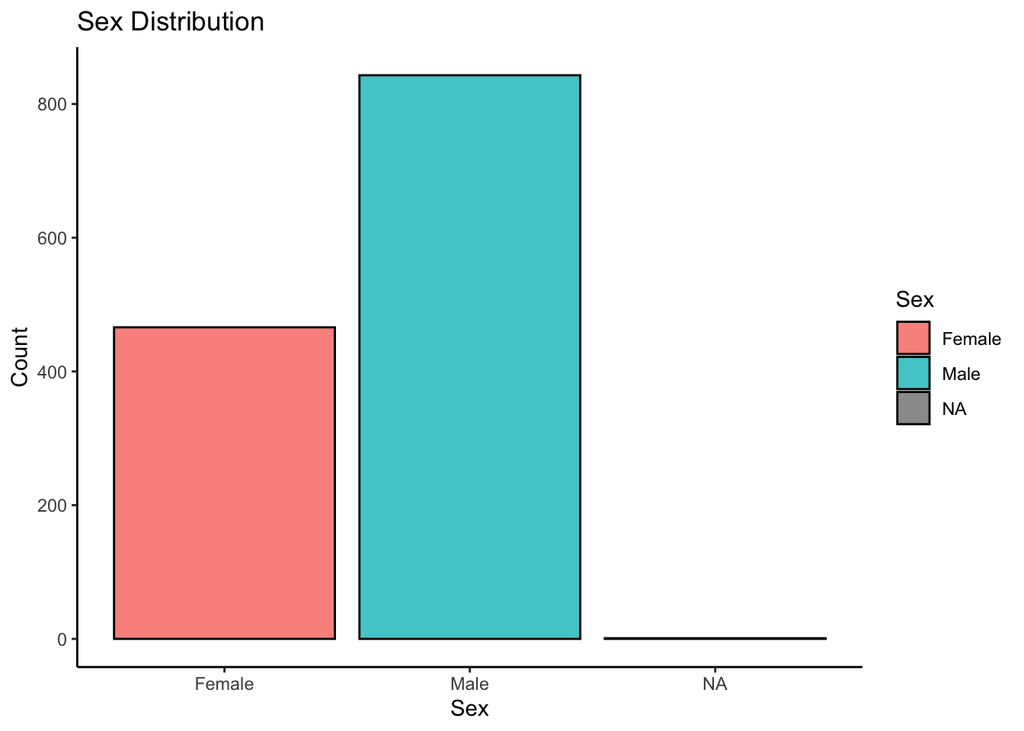

```r
# if we want to filter `na` we can simply say
# titanic<-titanic %>%
#  filter(!is.na(Sex))
# however, we are not cleaning the data.

ggplot(data = titanic) +
    geom_bar(mapping = aes(x=Sex, fill=Sex), col = "black", alpha = 0.8) +
    labs(x = "Sex", y = "Count", title = "Sex Distribution") +
    theme_classic()
```

Since sex is a categorical variable we use a bar chart. The bar chart shows that there is 1 `NA` sex which can indicate that the gender is missing for the individual, the bar chart displays that the number of males is greater than females.

We can display the following by using the `count`. The count function generates an error when using `NA` with factors so we remove the `NA`

```r
titanic<-titanic %>%
 filter(!is.na(Sex))
```

```r
titanic %>%
  count(Sex)
```

```
## # A tibble: 2 x 2
##   Sex        n
##   <fct>  <int>
## 1 Female   466
## 2 Male     843
```

To examin the distribution of the `Age` we will use a histogram chart.

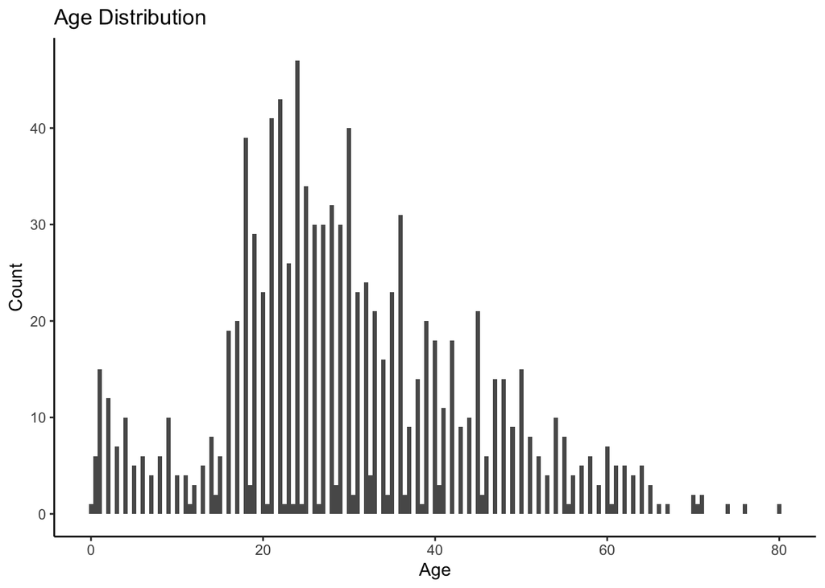

```r
ggplot(data = titanic) +
      geom_histogram(mapping = aes(x = Age), binwidth = 0.5) +
      labs(x = "Age", y = "Count", title = "Age Distribution") +
        theme_classic()
```

The `age` distribution is plotted above in a histrogram which shows a `positive skewed` distribution, this can give an indication on the median if we plot this on a box and whiskers.

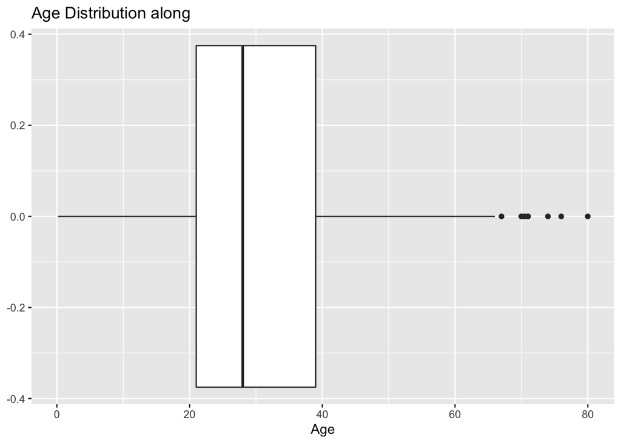

```r
 ggplot(data = titanic, mapping = aes(x = Age), horizontal = T, main= "Age Distribution of Passengers") +
   labs(x = "Age", title = "Age Distribution along") +
      geom_boxplot()
```

```r
summary(titanic$Age)
```

```
##    Min. 1st Qu.  Median    Mean 3rd Qu.    Max.    NA's
##  0.1667 21.0000 28.0000 29.8811 39.0000 80.0000     263
```

the following observation if we calculate the number of people with age respectively and display them in a tabular format.

```r
titanic %>%
      count(cut_width(Age, 0.5))
```

```
## # A tibble: 94 x 2
##    `cut_width(Age, 0.5)`     n
##    <fct>                 <int>
##  1 [-0.25,0.25]              1
##  2 (0.25,0.75]               6
##  3 (0.75,1.25]              15
##  4 (1.75,2.25]              12
##  5 (2.75,3.25]               7
##  6 (3.75,4.25]              10
##  7 (4.75,5.25]               5
##  8 (5.75,6.25]               6
##  9 (6.75,7.25]               4
## 10 (7.75,8.25]               6
## # … with 84 more rows
```

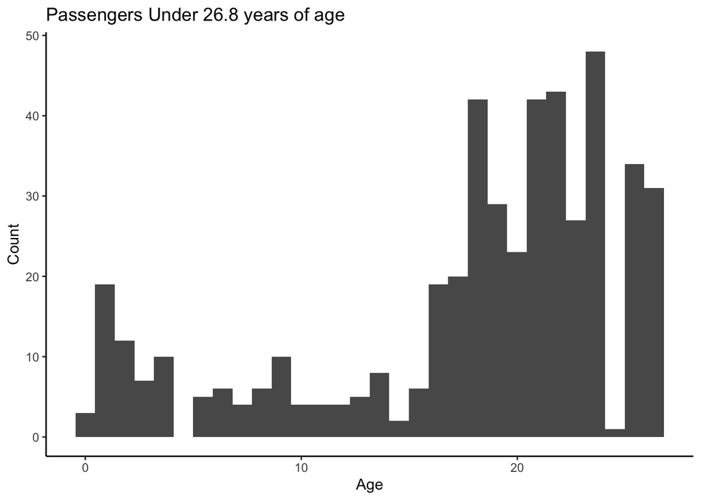

```r
young<- titanic %>%
    filter(Age<26.8)

## then we can plot data
ggplot(data = young) +
      geom_histogram(mapping = aes(x = Age)) +
      labs(x = "Age", y = "Count", title = "Passengers Under 26.8 years of age") +
        theme_classic()
```

we notice how quickly the observation have changed, now it’s showing a `negatively skewed distribution` towards the right.If we use a histrogram and correlate with the Age/Sex it might give us a better indication.Hence, we can observe that the Males younger on the ship are more in numbers with comparison the females.

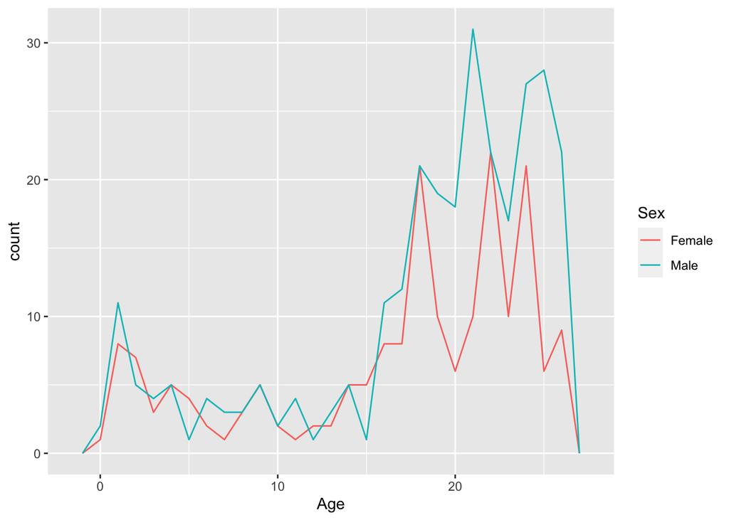

```r
ggplot(data = young, mapping = aes(x = Age, color = Sex)) +
      geom_freqpoly(binwidth = 1)
```